# Study of Logistic Regression

Digvijay Kawale

2/4/2020

# Project Part 2: Study of Logistic Regression

## Loading the required Packages

```r
library(tidyverse)
library(readxl)
library(dplyr)
library(corrr)
library(MASS)
library(psych)
```

## Step 0: Getting the cleaned data set from steps 1 to 9 of Project Part 1.

- The final data set that we used for the study of linear regression had 832 observations of 8 variables. The same data set is obtained using the steps followed in the project part 1.Those steps are outlined as comments in the below code part.

```r
## Loading Data Sets

Flights_800 <- read_xls("~/Desktop/Subjects/Flex 3/Statistical Modelling/WeeK 1/FAA1-1.xls")
Flights_150 <- read_xls("~/Desktop/Subjects/Flex 3/Statistical Modelling/WeeK 1/FAA2-1.xls")

## Merging Two Data Sets and removing duplicates

Flights_150$duration <- NA

flights_final <- rbind(Flights_800, Flights_150)

flights_columns <- flights_final[c("aircraft"   ,  "no_pasg"   ,   "speed_ground" ,"speed_air"   , "height"   ,    "pitch"   , "distance"  )]

flights_final <- flights_final[!duplicated(flights_columns),]

## Removing abnormal observations from the data set

flights_final <- filter(flights_final, ifelse(is.na(height), TRUE, height >= 6))

flights_final <- filter(flights_final, ifelse(is.na(speed_ground), TRUE, (speed_ground >= 30 & speed_ground <= 140)))

flights_final <- filter(flights_final, ifelse(is.na(speed_air), TRUE, (speed_air >= 30 & speed_air <= 140)))

flights_final <- filter(flights_final, ifelse(is.na(duration), TRUE, duration >= 40 ))

dim(flights_final)
```

```
## [1] 832   8
```

# Creating Binary Responses

## Step 1: Cretaing the Binary Variables ‘long_landing’, ‘risky_landing’ and removing the continous variable for ‘distance’.

- A binary response of long landing is created based on the varible distance. If the distance is greater than 2500 then variable long landing will be 1 else it will be 0.
- A binary response of risky landing is created based on the varible distance. If the distance is greater than 3000 then variable risky landing will be 1 else it will be 0.

```r
## Adding Binary Variables

flights_final$long_landing <- ifelse(flights_final$distance > 2500, 1, 0)

flights_final$risky_landing <- ifelse(flights_final$distance > 3000, 1, 0)

## Discarding the Continous variable 'distance'

flights_final$distance <- NULL
```

# Identifying important factors using the binary data of “long_landing”

## Step 2: Histogram showing the distribution of long_landing

- It is observed that 104 observations of long_landing have the value 1 and the rest 728 have the value 0.

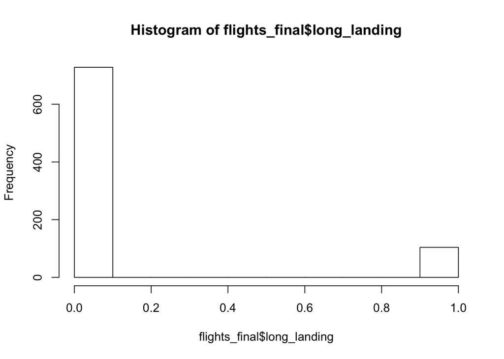

```r
hist(flights_final$long_landing)
```

## Step 3: Fitting single-factor logistic regression

- The variable Long Landing is logistically regressed with all the variables one by one.
- Later the results of all the regression models are tabulated in table 1 that contains the size regression coefficient, direction of coeficient, odds ratio and p values.
- Using p- values from the table 1, it is observed that the significant predictor variables are speed_air, speed_ground, pitch and aircraft_num.

```r
## Converting the variable 'aircraft' into binary

flights_final$aircraft_num <-  ifelse(flights_final$aircraft == "airbus", 1, 0)

## Fitting single-factor logistic regression using each variable

duration <-  glm(long_landing ~ duration, family = binomial, data = flights_final)
no_pasg <- glm(long_landing ~ no_pasg, family = binomial, data = flights_final)
speed_ground <- glm(long_landing ~ speed_ground, family = binomial, data = flights_final)
speed_air <- glm(long_landing ~ speed_air, family = binomial, data = flights_final)
height <- glm(long_landing ~ height, family = binomial, data = flights_final)
pitch <- glm(long_landing ~ pitch, family = binomial, data = flights_final)
aircraft_num <- glm(long_landing ~ aircraft_num, family = binomial, data = flights_final)


##Calculating odds ratio

odds_ratio <- c(
exp(summary(duration)$coefficients[2,1]),
exp(summary(no_pasg)$coefficients[2,1]),
exp(summary(speed_ground)$coefficients[2,1]),
exp(summary(speed_air)$coefficients[2,1]),
exp(summary(height)$coefficients[2,1]),
exp(summary(pitch)$coefficients[2,1]),
exp(summary(aircraft_num)$coefficients[2,1]))


## Creating Variable names vector

variable_names <- c("duration", "no_pasg", "speed_ground", "speed_air",  "height", "pitch", "aircraft_num")


## P values

p_values <- c(
summary(duration)$coefficients[2,4],
summary(no_pasg)$coefficients[2,4],
summary(speed_ground)$coefficients[2,4],
summary(speed_air)$coefficients[2,4],
summary(height)$coefficients[2,4],
summary(pitch)$coefficients[2,4],
summary(aircraft_num)$coefficients[2,4])

## Regression Coefficients

regression_coefficients <- c(
summary(duration)$coefficients[2,1],
summary(no_pasg)$coefficients[2,1],
summary(speed_ground)$coefficients[2,1],
summary(speed_air)$coefficients[2,1],
summary(height)$coefficients[2,1],
summary(pitch)$coefficients[2,1],
summary(aircraft_num)$coefficients[2,1])

Table_1 <- data.frame(variable_names, regression_coefficients, odds_ratio, coef_direction = ifelse(regression_coefficients < 0, "Negative", "Positive") , p_values)

Table_1
```

| variable_names | regression_coefficients | odds_ratio | coef_direction | p_values |
| --- | --- | --- | --- | --- |
| duration | -0.001211113 | 0.9987896 | Negative | 5.850450e-01 |
| no_pasg | -0.006523928 | 0.9934973 | Negative | 6.414223e-01 |
| speed_ground | 0.472345761 | 1.6037518 | Positive | 3.935303e-14 |
| speed_air | 0.512321769 | 1.6691621 | Positive | 4.333606e-11 |
| height | 0.009923535 | 1.0099729 | Positive | 3.530158e-01 |
| pitch | 0.403385772 | 1.4968842 | Positive | 4.436662e-02 |
| aircraft_num | -0.878934945 | 0.4152249 | Negative | 6.090379e-05 |

## Step 4 : Seeing the association of long landing

- The significance of variables is checked using the p values. The models having p-values less than 0.05 are considered as significant.
- The significant predictor variables observed in table_1 are speed_air, speed_ground, pitch and aircraft_num.

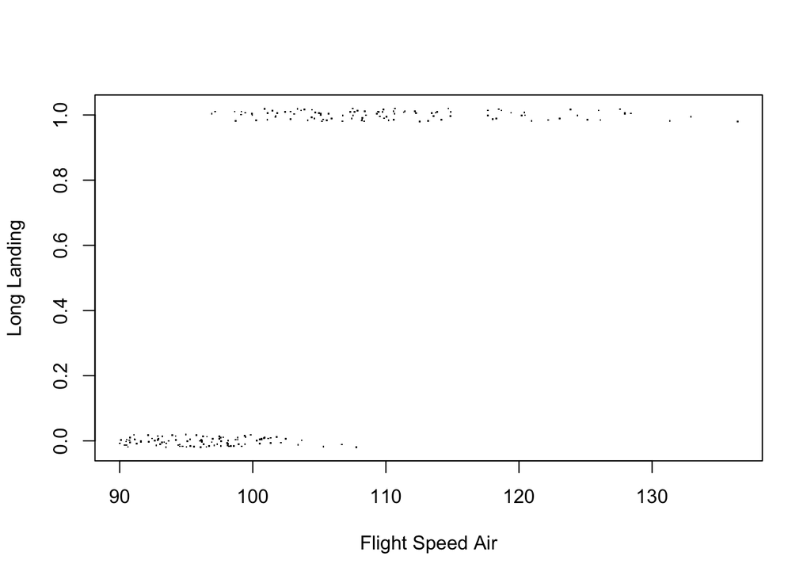

```r
##Speed_air

plot(jitter(long_landing,0.1) ~ jitter(speed_air), flights_final, xlab = "Flight Speed Air", ylab = "Long Landing", pch = ".")
```

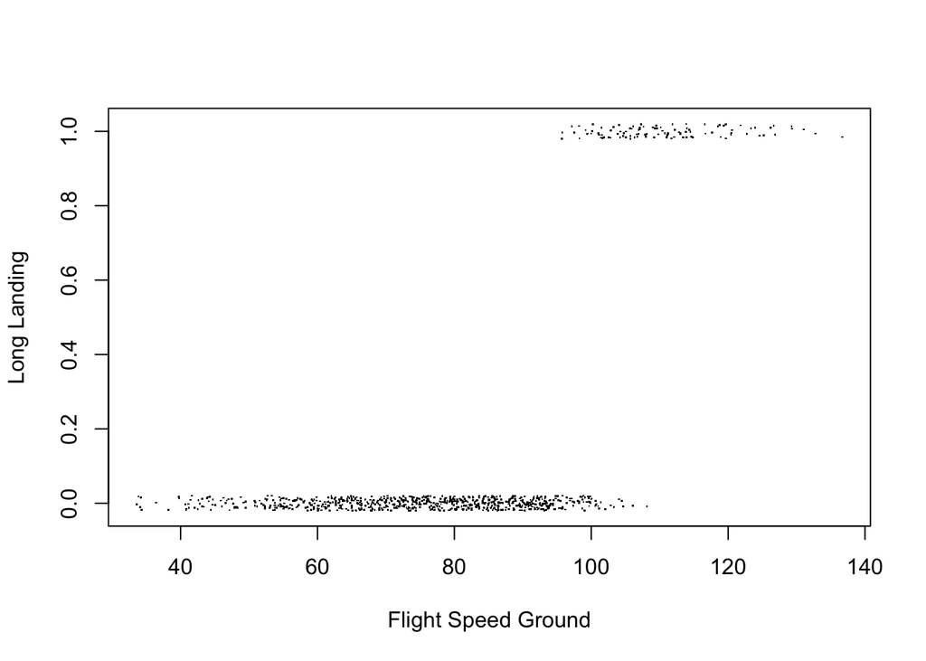

```r
##Speed_ground

plot(jitter(long_landing,0.1) ~ jitter(speed_ground), flights_final, xlab = "Flight Speed Ground", ylab = "Long Landing", pch = ".")
```

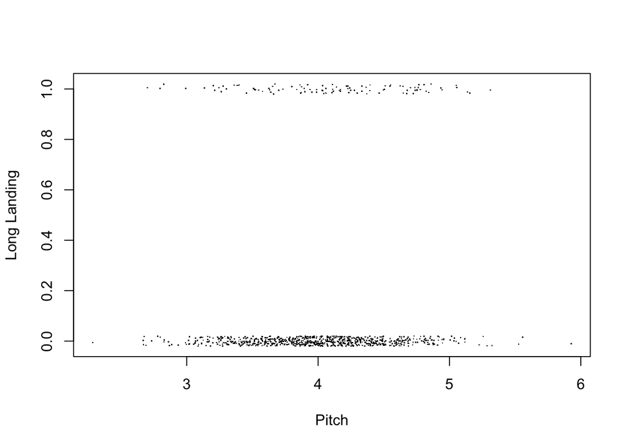

```r
##Pitch

plot(jitter(long_landing,0.1) ~ jitter(pitch), flights_final, xlab = "Pitch", ylab = "Long Landing", pch = ".")
```

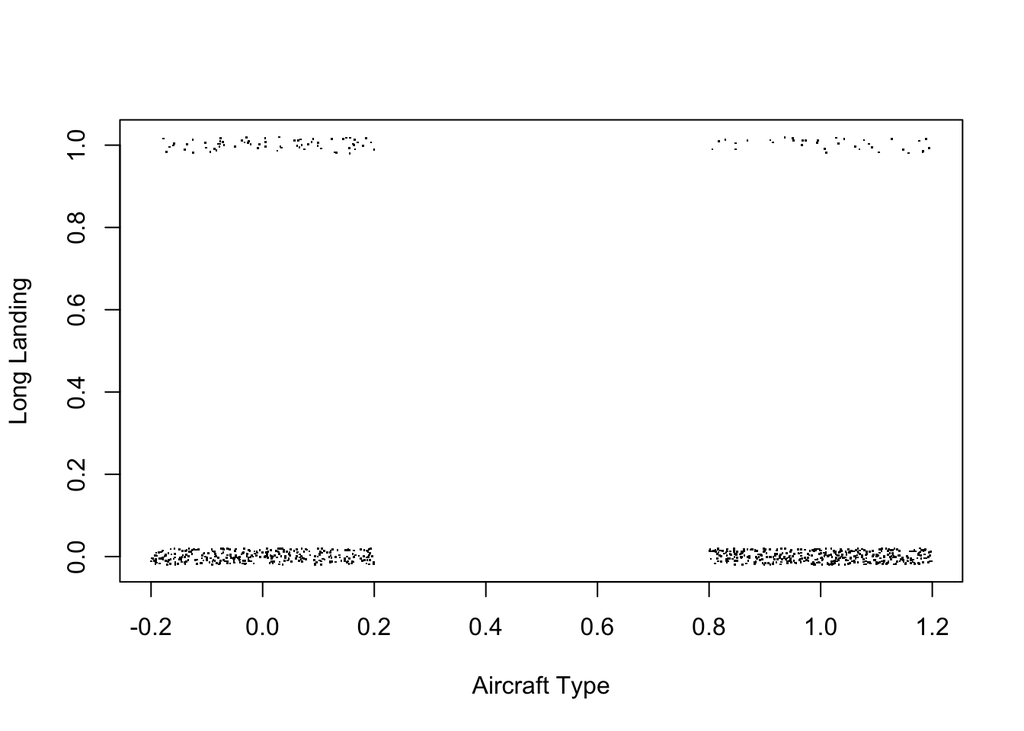

```r
##Aircraft Numeric

plot(jitter(long_landing,0.1) ~ jitter(aircraft_num), flights_final, xlab = "Aircraft Type", ylab = "Long Landing", pch = ".")
```

## Step 5: Fitting the data with all variables together

- It ws observed in step 16 of Project part 1 that the speed air and speed ground were highly collinear. We used speed ground as predictor because the number of NA’s in data were high for speed air. Also, speed ground was more significant than speeed air.
- We will now fit a logistic regression using three variables together. The varibles that we will use are speed_ground, pitch and aircraft numeric.
- The full model logistetic regression model tells us that wih a unit increase in Speed Ground the odds ratio will increase by 1.849 when all other variables are kept constant.
- The full model logistetic regression model tells us that wih a unit increase in Pitch the odds ratio will increase by 2.9 when all other variables are kept constant.
- The full model logistetic regression model tells us that wih a unit increase in Aircraft Numeric the odds ratio will increase by 0.047 when all other variables are kept constant.

```r
full_model <-  glm(long_landing ~ speed_ground + pitch + aircraft_num, family = binomial, data = flights_final)
## Calculating odds ratio

odds_ratio_full_model <- c(
exp(summary(full_model)$coefficients[2,1]),
exp(summary(full_model)$coefficients[3,1]),
exp(summary(full_model)$coefficients[4,1]))

summary(full_model)
```

```
##
## Call:
## glm(formula = long_landing ~ speed_ground + pitch + aircraft_num,
##     family = binomial, data = flights_final)
##
## Deviance Residuals:
##      Min        1Q    Median        3Q       Max
## -2.11589  -0.01114  -0.00026   0.00000   2.40741
##
## Coefficients:
##               Estimate Std. Error z value Pr(>|z|)
## (Intercept)  -64.88507   10.11708  -6.413 1.42e-10 ***
## speed_ground   0.61471    0.09184   6.694 2.18e-11 ***
## pitch          1.06599    0.60389   1.765   0.0775 .
## aircraft_num  -3.04348    0.73345  -4.150 3.33e-05 ***
## ---
## Signif. codes:  0 '***' 0.001 '**' 0.01 '*' 0.05 '.' 0.1 ' ' 1
##
## (Dispersion parameter for binomial family taken to be 1)
##
##     Null deviance: 626.946  on 831  degrees of freedom
## Residual deviance:  81.309  on 828  degrees of freedom
## AIC: 89.309
##
## Number of Fisher Scoring iterations: 10
```

## Step 6: Step Wise AIC

```r
## Filtering the character variable aircraft and speed air

flights_1 <- dplyr::select(flights_final, duration, no_pasg, speed_ground, height, pitch, aircraft_num, long_landing)

GLM_long_landing_null <- glm(long_landing ~ 1, family = binomial, data = flights_1)
GLM_long_landing_full <- glm(long_landing ~ ., family = binomial, data = flights_1)
fit1_GLM <- step(GLM_long_landing_null, scope = list(lower =GLM_long_landing_null,upper = GLM_long_landing_full),    direction = 'forward')
```

```
## Start:  AIC=628.95
## long_landing ~ 1
```

```
##                Df Deviance    AIC
## + speed_ground  1   107.40 136.55
## + aircraft_num  1   586.99 616.14
## + pitch         1   599.11 628.26
## <none>              601.79 628.95
## + height        1   601.21 630.36
## + duration      1   601.50 630.65
## + no_pasg       1   601.60 630.75
```

```
##
## Step:  AIC=119.47
## long_landing ~ speed_ground
```

```
##                Df Deviance     AIC
## + aircraft_num  1   78.164  92.233
## + height        1   95.059 109.129
## + pitch         1   97.006 111.076
## <none>             107.401 119.470
## + duration      1  107.296 121.365
## + no_pasg       1  107.375 121.444
```

```
##
## Step:  AIC=90.66
## long_landing ~ speed_ground + aircraft_num
```

```
##            Df Deviance    AIC
## + height    1   54.401 68.902
## + pitch     1   75.176 89.677
## <none>          78.164 90.665
## + duration  1   76.635 91.136
## + no_pasg   1   77.824 92.325
```

```
##
## Step:  AIC=65.05
## long_landing ~ speed_ground + aircraft_num + height
```

```
##            Df Deviance    AIC
## + pitch     1   51.580 64.225
## <none>          54.401 65.047
## + duration  1   53.680 66.325
## + no_pasg   1   54.401 67.047
```

```
##
## Step:  AIC=63.2
## long_landing ~ speed_ground + aircraft_num + height + pitch
```

```
##            Df Deviance    AIC
## <none>          51.580 63.204
## + duration  1   51.102 64.726
## + no_pasg   1   51.575 65.199
```

## Step 7: Step Wise BIC

```r
fit2_GLM <- step(GLM_long_landing_null, scope = list(lower =GLM_long_landing_null,upper = GLM_long_landing_full),    direction = 'forward', k = log(nrow(flights_1)))
```

```
## Start:  AIC=633.67
## long_landing ~ 1
```

```
##                Df Deviance    AIC
## + speed_ground  1   107.40 146.00
## + aircraft_num  1   586.99 625.59
## <none>              601.79 633.67
## + pitch         1   599.11 637.71
## + height        1   601.21 639.81
## + duration      1   601.50 640.09
## + no_pasg       1   601.60 640.20
```

```
##
## Step:  AIC=128.92
## long_landing ~ speed_ground
```

```
##                Df Deviance    AIC
## + aircraft_num  1   78.164 106.41
## + height        1   95.059 123.30
## + pitch         1   97.006 125.25
## <none>             107.401 128.92
## + duration      1  107.296 135.54
## + no_pasg       1  107.375 135.62
```

```
##
## Step:  AIC=104.84
## long_landing ~ speed_ground + aircraft_num
```

```
##            Df Deviance     AIC
## + height    1   54.401  87.798
## <none>          78.164 104.836
## + pitch     1   75.176 108.572
## + duration  1   76.635 110.031
## + no_pasg   1   77.824 111.220
```

```
##
## Step:  AIC=83.94
## long_landing ~ speed_ground + aircraft_num + height
```

```
##            Df Deviance    AIC
## <none>          54.401 83.942
## + pitch     1   51.580 87.844
## + duration  1   53.680 89.944
## + no_pasg   1   54.401 90.666
```

## Step 8: Meeting with the FAA agent

- We will be modelling the variable landing distance using the two predictors - speed ground and aircraft numeric. They are the most important variables as they high association with our response variable.
- We observe that with a unit increase in speed ground, the odds ratio increases by 1.795 when the variable aircraft numeric is kept constant.
- We observe that with a unit increase in aircraft numeric (Basically here we are changing the aircraft type) the odds ratio increases by 0.039 when the variable speed_ground is kept constant.

```r
presentation_model <- glm(long_landing ~ speed_ground + aircraft_num, family = binomial, data = flights_1)
odds_ratio_presentation <- c(
exp(summary(presentation_model)$coefficients[2,1]),
exp(summary(presentation_model)$coefficients[3,1]))

summary(presentation_model)
```

```
##
## Call:
## glm(formula = long_landing ~ speed_ground + aircraft_num, family = binomial,
##     data = flights_1)
##
## Deviance Residuals:
##      Min        1Q    Median        3Q       Max
## -2.28368  -0.01417  -0.00039   0.00000   2.56541
##
## Coefficients:
##               Estimate Std. Error z value Pr(>|z|)
## (Intercept)  -57.53370    8.24419  -6.979 2.98e-12 ***
## speed_ground   0.58534    0.08441   6.934 4.08e-12 ***
## aircraft_num  -3.23679    0.71189  -4.547 5.45e-06 ***
## ---
## Signif. codes:  0 '***' 0.001 '**' 0.01 '*' 0.05 '.' 0.1 ' ' 1
##
## (Dispersion parameter for binomial family taken to be 1)
##
##     Null deviance: 626.946  on 831  degrees of freedom
## Residual deviance:  84.665  on 829  degrees of freedom
## AIC: 90.665
##
## Number of Fisher Scoring iterations: 10
```

# Step 9 : Repeating Steps 1-7 for the binary variable Risky Landing

## Step 1 (Risk Landing)

- A binary response of risky landing is created based on the varible distance. If the distance is greater than 3000 then variable risky landing will be 1 else it will be 0.

## Step 2 (Risky Landing): Histogram showing the distribution of risky_landing

- It is observed that 62 observations of risky_landing have the value 1 and the rest 770 have the value 0.

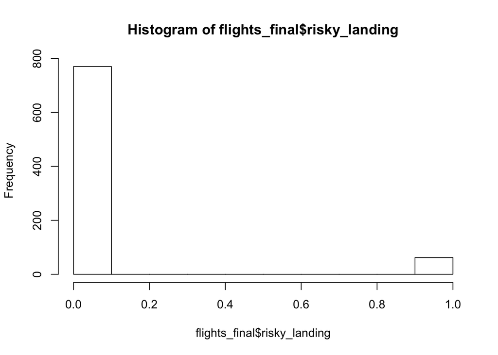

```r
hist(flights_final$risky_landing)
```

## Step 3 (Risky Landing) : Fitting single-factor logistic regression

- The variable Risky Landing is logistically regressed with all the variables one by one.
- Later the results of all the regression models are tabulated in table 2 that contains the size regression coefficient, direction of coeficient, odds ratio and p values.
- Using p- values from the table 2, it is observed that the significant predictor variables are speed_air, speed_ground, and aircraft_num.

```r
## Fitting single-factor logistic regression using each variable

duration_1 <-  glm(risky_landing ~ duration, family = binomial, data = flights_final)
no_pasg_1 <- glm(risky_landing ~ no_pasg, family = binomial, data = flights_final)
speed_ground_1 <- glm(risky_landing ~ speed_ground, family = binomial, data = flights_final)
speed_air_1 <- glm(risky_landing ~ speed_air, family = binomial, data = flights_final)
height_1 <- glm(risky_landing ~ height, family = binomial, data = flights_final)
pitch_1 <- glm(risky_landing ~ pitch, family = binomial, data = flights_final)
aircraft_num_1 <- glm(risky_landing ~ aircraft_num, family = binomial, data = flights_final)


##Calculating odds ratio

odds_ratio_1 <- c(
exp(summary(duration_1)$coefficients[2,1]),
exp(summary(no_pasg_1)$coefficients[2,1]),
exp(summary(speed_ground_1)$coefficients[2,1]),
exp(summary(speed_air_1)$coefficients[2,1]),
exp(summary(height_1)$coefficients[2,1]),
exp(summary(pitch_1)$coefficients[2,1]),
exp(summary(aircraft_num_1)$coefficients[2,1]))


## P values

p_values_1 <- c(
summary(duration_1)$coefficients[2,4],
summary(no_pasg_1)$coefficients[2,4],
summary(speed_ground_1)$coefficients[2,4],
summary(speed_air_1)$coefficients[2,4],
summary(height_1)$coefficients[2,4],
summary(pitch_1)$coefficients[2,4],
summary(aircraft_num_1)$coefficients[2,4])

## Regression Coefficients

regression_coefficients_1 <- c(
summary(duration_1)$coefficients[2,1],
summary(no_pasg_1)$coefficients[2,1],
summary(speed_ground_1)$coefficients[2,1],
summary(speed_air_1)$coefficients[2,1],
summary(height_1)$coefficients[2,1],
summary(pitch_1)$coefficients[2,1],
summary(aircraft_num_1)$coefficients[2,1])

Table_2 <- data.frame(variable_names, regression_coefficients_1, odds_ratio_1, coef_direction = ifelse(regression_coefficients_1 < 0, "Negative", "Positive") , p_values_1)

Table_2
```

| variable_names | regression_coefficients_1 | odds_ratio_1 | coef_direction | p_values_1 |
| --- | --- | --- | --- | --- |
| duration | -0.0013826041 | 0.9986184 | Negative | 6.185950e-01 |
| no_pasg | -0.0238804478 | 0.9764024 | Negative | 1.762083e-01 |
| speed_ground | 0.6142187540 | 1.8482121 | Positive | 6.897975e-08 |
| speed_air | 0.8704019017 | 2.3878703 | Positive | 3.728025e-06 |
| height | 0.0001493793 | 1.0001494 | Positive | 9.911654e-01 |
| pitch | 0.3755782194 | 1.4558330 | Positive | 1.358414e-01 |
| aircraft_num | -1.0253058273 | 0.3586868 | Negative | 3.183632e-04 |

## Step 4 (Risky Landing) : Seeing the association of Risky landing

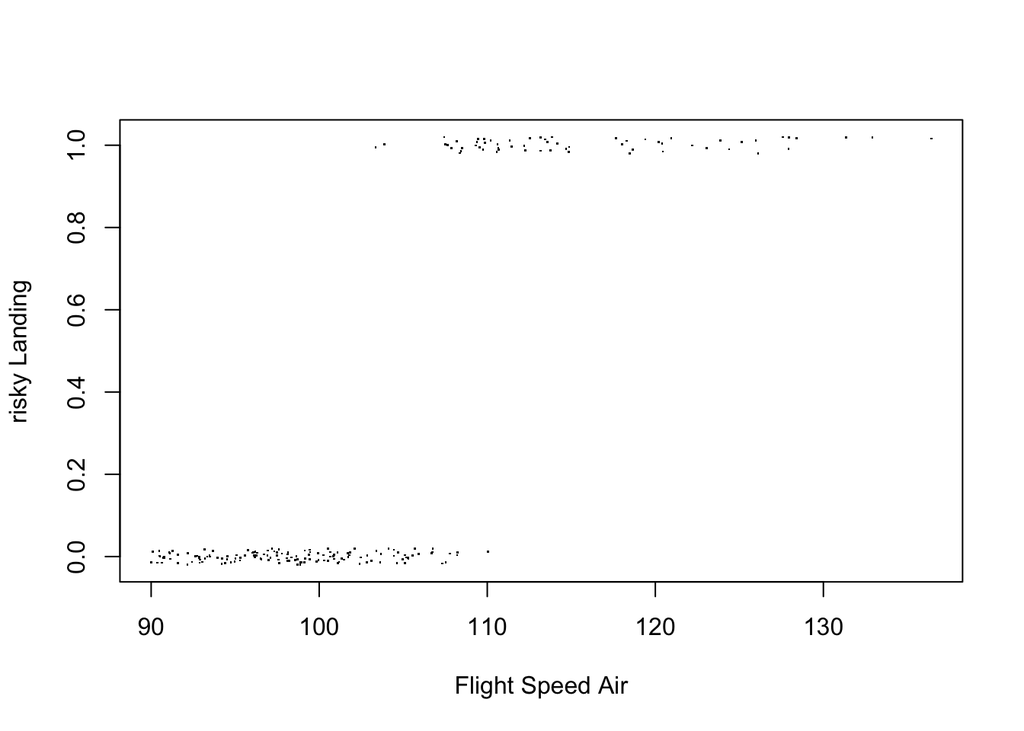

```r
##Speed_air

plot(jitter(risky_landing,0.1) ~ jitter(speed_air), flights_final, xlab = "Flight Speed Air", ylab = "risky Landing", pch = ".")
```

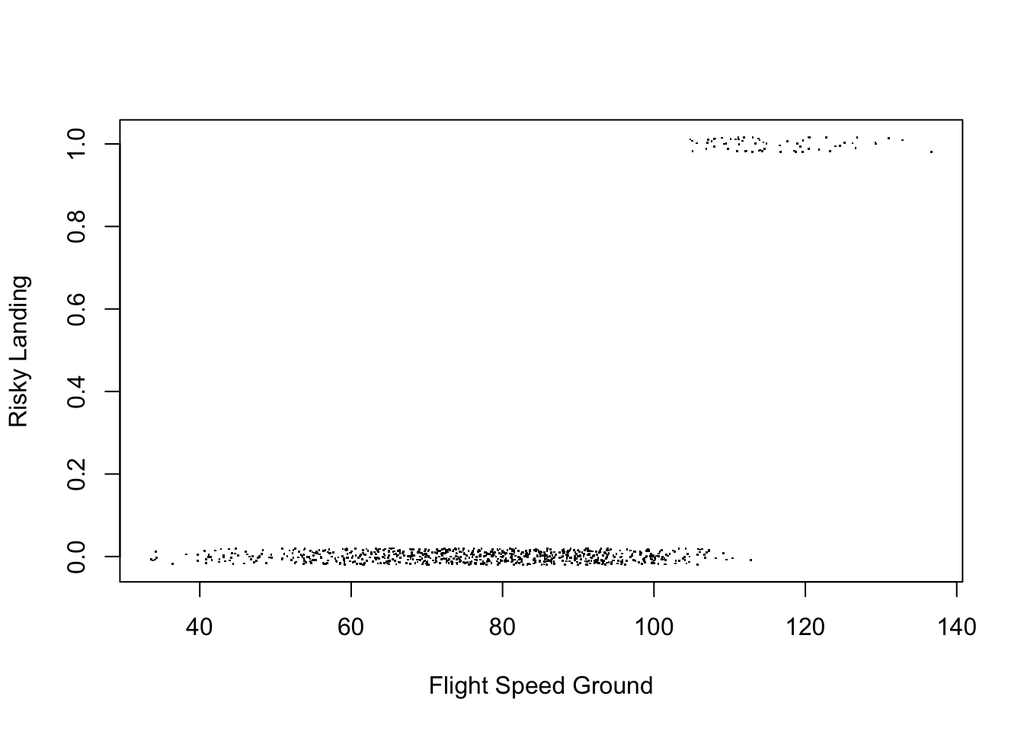

```r
##Speed_ground

plot(jitter(risky_landing,0.1) ~ jitter(speed_ground), flights_final, xlab = "Flight Speed Ground", ylab = "Risky Landing", pch = ".")
```

[figure not shown]

```r
##Aircraft Numeric

plot(jitter(risky_landing,0.1) ~ jitter(pitch), flights_final, xlab = "Aircraft Numeric", ylab = "Risky Landing", pch = ".")
```

## Step 5 (Risky Landing) : Fitting the data with all variables together

- It ws observed in step 16 of Project part 1 that the speed air and speed ground were highly collinear. We used speed ground as predictor because the number of NA’s in data were high for speed air. Also, speed ground was more significant than speeed air.
- We will now fit a logistic regression using two variables together. The varibles that we will use are speed_ground and aircraft numeric.
- The full model logistetic regression model tells us that wih a unit increase in Speed Ground the odds ratio will increase by 2.52 when all other variables are kept constant.
- The full model logistetic regression model tells us that wih a unit increase in Aircraft Numeric the odds ratio will increase by 0.017 when all other variables are kept constant.

```r
full_model_1 <-  glm(risky_landing ~ speed_ground + aircraft_num, family = binomial, data = flights_final)
## Calculating odds ratio

odds_ratio_full_model_1 <- c(
exp(summary(full_model_1)$coefficients[2,1]),
exp(summary(full_model_1)$coefficients[3,1]))

summary(full_model_1)
```

```
##
## Call:
## glm(formula = risky_landing ~ speed_ground + aircraft_num, family = binomial,
##     data = flights_final)
##
## Deviance Residuals:
##      Min        1Q    Median        3Q       Max
## -2.24398  -0.00011   0.00000   0.00000   1.61021
##
## Coefficients:
##              Estimate Std. Error z value Pr(>|z|)
## (Intercept)  -98.0582    23.8303  -4.115 3.87e-05 ***
## speed_ground   0.9263     0.2248   4.121 3.78e-05 ***
## aircraft_num  -4.0190     1.2494  -3.217   0.0013 **
## ---
## Signif. codes:  0 '***' 0.001 '**' 0.01 '*' 0.05 '.' 0.1 ' ' 1
##
## (Dispersion parameter for binomial family taken to be 1)
##
##     Null deviance: 441.251  on 831  degrees of freedom
## Residual deviance:  40.097  on 829  degrees of freedom
## AIC: 46.097
##
## Number of Fisher Scoring iterations: 12
```

## Step 6 (Risky Landing) : Step Wise AIC

- We will use the Stepwise AIC funtion in R to do the variable selection for the full model of Logistic Regression.
- Before doing that we will remove the character variable aircraft type from the data frame as we have already coded it as binary. We will also remove the speed air variable as it has a lot of NULL values and it is highly collinear with speed ground.
- After applying the step AIC function to the model, is shows that it has lowest AIC of 45.71 when the variables speed_ground, aicraft_num and no_pasg are selected. The AIC for the model with variables speed_ground and aircraft_num is 46.1. Since this difference is small we will choose speed ground and aicraft_numeric as the predictor variables. Another reason behind that is we have already seen that no_pasg was less significant in the earlier steps.

```r
flights_2 <- dplyr::select(flights_final, duration, no_pasg, speed_ground, height, pitch, aircraft_num, risky_landing)

GLM_long_landing_null_1 <- glm(risky_landing ~ 1, family = binomial, data = flights_2)
GLM_long_landing_full_1 <- glm(risky_landing ~ ., family = binomial, data = flights_2)
fit1_GLM_1 <- step(GLM_long_landing_null_1, scope = list(lower =GLM_long_landing_null_1,upper = GLM_long_landing_full_1),    direction = 'forward')
```

```
## Start:  AIC=443.25
## risky_landing ~ 1
```

```
##                Df Deviance    AIC
## + speed_ground  1    57.99  74.91
## + aircraft_num  1   416.49 433.41
## <none>              428.33 443.25
## + no_pasg       1   426.50 443.42
## + pitch         1   426.59 443.51
## + duration      1   428.08 445.00
## + height        1   428.32 445.24
```

```
##
## Step:  AIC=62.93
## risky_landing ~ speed_ground
```

```
##                Df Deviance    AIC
## + aircraft_num  1   39.955 46.898
## + pitch         1   51.634 58.576
## <none>              57.988 62.931
## + no_pasg       1   57.178 64.121
## + height        1   57.787 64.729
## + duration      1   57.951 64.893
```

```
##
## Step:  AIC=46.1
## risky_landing ~ speed_ground + aircraft_num
```

```
##            Df Deviance    AIC
## + no_pasg   1   37.559 45.700
## <none>          39.955 46.097
## + height    1   39.295 47.436
## + duration  1   39.757 47.898
## + pitch     1   39.783 47.924
```

```
##
## Step:  AIC=45.71
## risky_landing ~ speed_ground + aircraft_num + no_pasg
```

```
##            Df Deviance    AIC
## <none>          37.559 45.707
## + height    1   36.985 47.133
## + pitch     1   37.304 47.452
## + duration  1   37.548 47.696
```

## Step 7 (Risky Landing) : Step Wise BIC

- The step function in R can also be used with BIC as our parameter. We will give an extra argument ‘k = log(nrow(flights_1))’ in the step function. The use of this function for BIC was found through google search. Here is its [link](https://www.rdocumentation.org/packages/stats/versions/3.6.2/topics/step)
- We observe similar kind of results in stepwise BIC as well. The minimum BIC of 60.27 is observed when the variable speed_ground and aircraft numerice are used as predictor variables.
- Therefore, the final variables that we will be using as predictors are speed ground and aircraft_numeric.

```r
fit2_GLM_1 <- step(GLM_long_landing_null_1, scope = list(lower =GLM_long_landing_null_1,upper = GLM_long_landing_full_1),    direction = 'forward', k = log(nrow(flights_1)))
```

```
## Start:  AIC=447.97
## risky_landing ~ 1
```

```
##                Df Deviance    AIC
## + speed_ground  1    57.99  84.35
## + aircraft_num  1   416.49 442.86
## <none>              428.33 447.97
## + no_pasg       1   426.50 452.87
## + pitch         1   426.59 452.96
## + duration      1   428.08 454.45
## + height        1   428.32 454.68
```

```
##
## Step:  AIC=72.38
## risky_landing ~ speed_ground
```

```
##                Df Deviance    AIC
## + aircraft_num  1   39.955 61.069
## <none>              57.988 72.378
## + pitch         1   51.634 72.748
## + no_pasg       1   57.178 78.292
## + height        1   57.787 78.901
## + duration      1   57.951 79.065
```

```
##
## Step:  AIC=60.27
## risky_landing ~ speed_ground + aircraft_num
```

```
##            Df Deviance    AIC
## <none>          39.955 60.268
## + no_pasg   1   37.559 64.596
## + height    1   39.295 66.332
## + duration  1   39.757 66.794
## + pitch     1   39.783 66.820
```

# Step 10 : Meeting the FAA agent

- We will be modelling the variable risky landing distance using the predictors - speed ground and aircraft numeirc. They are the most important variable as they have high association with our response variable.
- We observe that with a unit increase in speed ground, the odds ratio increases by 2.52 when other variables are kept constant.
- We observe that with a unit increase in aircraft_num, the odds ratio increases by 0.0179 when other variables are kept constant.

```r
presentation_model_1 <- glm(risky_landing ~ speed_ground  + aircraft_num, family = binomial, data = flights_2)
odds_ratio_presentation_1 <- c(
exp(summary(presentation_model_1)$coefficients[2,1]),
exp(summary(presentation_model_1)$coefficients[3,1]))

summary(presentation_model_1)
```

```
##
## Call:
## glm(formula = risky_landing ~ speed_ground + aircraft_num, family = binomial,
##     data = flights_2)
##
## Deviance Residuals:
##      Min        1Q    Median        3Q       Max
## -2.24398  -0.00011   0.00000   0.00000   1.61021
##
## Coefficients:
##              Estimate Std. Error z value Pr(>|z|)
## (Intercept)  -98.0582    23.8303  -4.115 3.87e-05 ***
## speed_ground   0.9263     0.2248   4.121 3.78e-05 ***
## aircraft_num  -4.0190     1.2494  -3.217   0.0013 **
## ---
## Signif. codes:  0 '***' 0.001 '**' 0.01 '*' 0.05 '.' 0.1 ' ' 1
##
## (Dispersion parameter for binomial family taken to be 1)
##
##     Null deviance: 441.251  on 831  degrees of freedom
## Residual deviance:  40.097  on 829  degrees of freedom
## AIC: 46.097
##
## Number of Fisher Scoring iterations: 12
```

## Step 12 : ROC Curves

- After plotting the ROC Curves for our final models we observe that the model built for risky landing is better than the model built for long landing. The area under the curve for the former model is greater than the latter one.

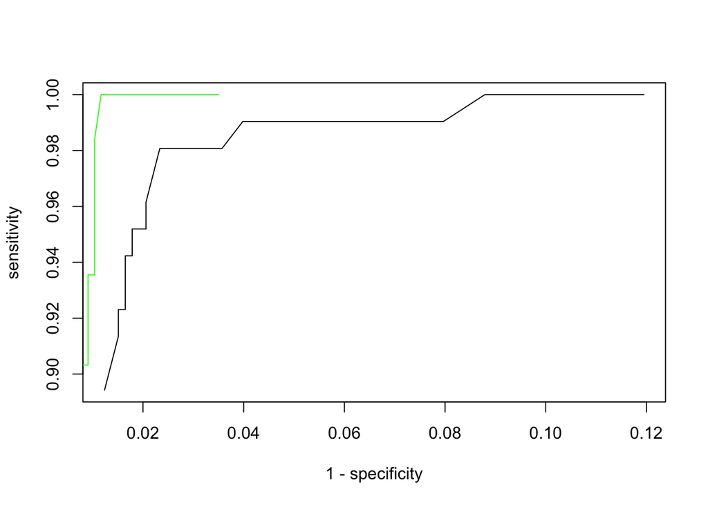

```r
## Long Landing Model


thresh <- seq(0.01, 0.5, 0.01)

pred_prob <- predict(presentation_model, type = "response")
pred_prob_1 <- predict(presentation_model_1, type = "response")


## Data Frames for Graphs

flights_1a <- data.frame(flights_1, pred_prob)

sensitivity <- specificity <- rep(NA, length(thresh))
for (j in seq(along = thresh)){
  pp <- ifelse(flights_1a$pred_prob < thresh[j], "no","yes")
  xx <- xtabs(~long_landing + pp, flights_1a)
  specificity[j] <- xx[1,1]/(xx[1,1] + xx[1,2])
  sensitivity[j] <- xx[2,2]/(xx[2,1] + xx[2,2])
}

flights_2a <- data.frame(flights_2, pred_prob_1)

sensitivity_1 <- specificity_1 <- rep(NA, length(thresh))
for (j in seq(along = thresh)){
  pp_1 <- ifelse(flights_2a$pred_prob_1 < thresh[j], "no","yes")
  xx_1 <- xtabs(~risky_landing + pp_1, flights_2a)
  specificity_1[j] <- xx_1[1,1]/(xx_1[1,1] + xx_1[1,2])
  sensitivity_1[j] <- xx_1[2,2]/(xx_1[2,1] + xx_1[2,2])
}


plot(1-specificity, sensitivity, type = "l"); abline(0,1, lty = 2)
lines(1-specificity_1,sensitivity_1,col="green")
```

## Step 13 : Predicting Probability for given observation

```r
new_obs <- data.frame(speed_ground = 115, aircraft_num = 0)

## Prediction of Probability of Long Landing
predict(presentation_model, newdata = new_obs, type = "response", se = T)
```

```
## $fit
##         1
## 0.9999434
##
## $se.fit
##            1
## 8.630534e-05
##
## $residual.scale
## [1] 1
```

```r
## Confidence Interval of Long Landing

round(c(0.9999434 - 1.96*8.630534e-05, 0.9999434 + 1.96*8.630534e-05 ), 4)
```

```
## [1] 0.9998 1.0001
```

```r
## Prediction of probability of Risky Landing

predict(presentation_model_1, newdata = new_obs, type = "response", se = T)
```

```
## $fit
##        1
## 0.999789
##
## $se.fit
##            1
## 0.0004408113
##
## $residual.scale
## [1] 1
```

```r
## Confidence Interval of Long Landing

round(c(0.999789  - 1.96*0.0004408113, 0.999789  + 1.96*0.0004408113), 4)
```

```
## [1] 0.9989 1.0007
```

## Step 14 : Fitting the Probit and Hazard model for the variable Risky Landing

```r
## Fitting a Probit Model

presentation_model_1_probit <- glm(risky_landing ~ speed_ground + aircraft_num, family = binomial(link = probit), flights_2)
## Fitting a C.Log Log Model

presentation_model_1_cloglog <- glm(risky_landing ~ speed_ground + aircraft_num, family = binomial(link = cloglog), flights_2)
## Comparing the models of risky landing

round(coef(presentation_model_1), 3)
```

```
##  (Intercept) speed_ground aircraft_num
##      -98.058        0.926       -4.019
```

```r
round(coef(presentation_model_1_probit), 3)
```

```
##  (Intercept) speed_ground aircraft_num
##      -56.336        0.532       -2.357
```

```r
round(coef(presentation_model_1_cloglog), 3)
```

```
##  (Intercept) speed_ground aircraft_num
##      -66.367        0.622       -2.898
```

## Step 15 : Comparing the ROC curves for all the three models

- After comparing the graphs of all three models we observe that the highest AUC is for the complementary log log model, then the probit model followed by the general linear model.
- The green graph represents probit model, the red represents the complementary log log model.

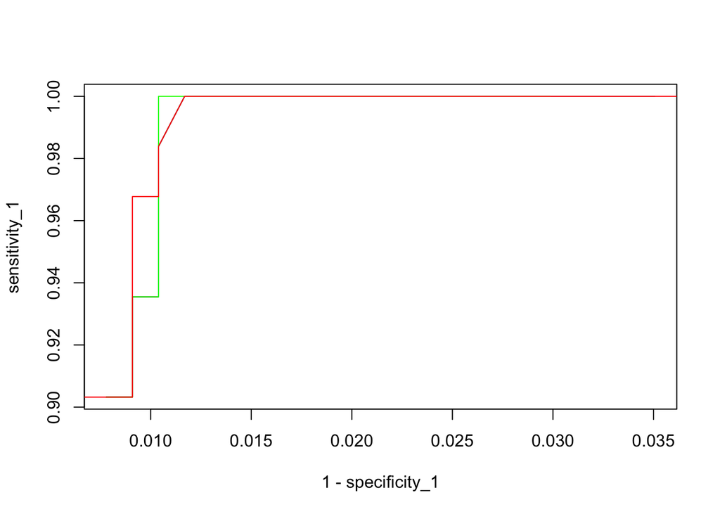

```r
pred_prob_1_probit <- predict(presentation_model_1_probit, type = "response")
pred_prob_1_cloglog <- predict(presentation_model_1_cloglog, type = "response")


flights_3a <- data.frame(flights_2, pred_prob_1, pred_prob_1_probit,pred_prob_1_cloglog)

sensitivity_1_probit <- specificity_1_probit <- rep(NA, length(thresh))
for (j in seq(along = thresh)){
  pp_1_probit <- ifelse(flights_3a$pred_prob_1_probit < thresh[j], "no","yes")
  xx_1_probit <- xtabs(~risky_landing + pp_1_probit, flights_3a)
  specificity_1_probit[j] <- xx_1_probit[1,1]/(xx_1_probit[1,1] + xx_1_probit[1,2])
  sensitivity_1_probit[j] <- xx_1_probit[2,2]/(xx_1_probit[2,1] + xx_1_probit[2,2])
}

sensitivity_1_cloglog <- specificity_1_cloglog <- rep(NA, length(thresh))
for (j in seq(along = thresh)){
  pp_1_cloglog <- ifelse(flights_3a$pred_prob_1_cloglog < thresh[j], "no","yes")
  xx_1_cloglog <- xtabs(~risky_landing + pp_1_cloglog, flights_3a)
  specificity_1_cloglog[j] <- xx_1_cloglog[1,1]/(xx_1_cloglog[1,1] + xx_1_cloglog[1,2])
  sensitivity_1_cloglog[j] <- xx_1_cloglog[2,2]/(xx_1_cloglog[2,1] + xx_1_cloglog[2,2])
}


plot(1-specificity_1, sensitivity_1, type = "l"); abline(0,1, lty = 2)
lines(1-specificity_1_probit,sensitivity_1_probit,col="green")
lines(1-specificity_1_cloglog,sensitivity_1_cloglog,col="red")
```

## Step 16: Top 5 Risky Landings

```r
## Top 5 Flights - General Linear model
top_n(flights_3a, 5, pred_prob_1)
```

| duration | no_pasg | speed_ground | height | pitch | aircraft_num | risky_landing | pred_prob_1 | pred_prob_1_probit | pred_prob_1_cloglog |
| --- | --- | --- | --- | --- | --- | --- | --- | --- | --- |
| 161.89247 | 72 | 129.2649 | 33.94900 | 4.139951 | 0 | 1 | 1 | 1 | 1 |
| 119.92455 | 64 | 136.6592 | 44.28611 | 4.169404 | 0 | 1 | 1 | 1 | 1 |
| 154.52460 | 67 | 129.3072 | 23.97850 | 5.154699 | 0 | 1 | 1 | 1 | 1 |
| 63.32952 | 52 | 132.7847 | 18.17703 | 4.110664 | 0 | 1 | 1 | 1 | 1 |
| 153.83445 | 61 | 126.8393 | 20.54783 | 4.334558 | 0 | 1 | 1 | 1 | 1 |

```r
## Top 5 Flights - Probit model
top_n(flights_3a, 5, pred_prob_1_probit)
```

| duration | no_pasg | speed_ground | height | pitch | aircraft_num | risky_landing | pred_prob_1 | pred_prob_1_probit | pred_prob_1_cloglog |
| --- | --- | --- | --- | --- | --- | --- | --- | --- | --- |
| 116.98454 | 67 | 122.7566 | 30.21657 | 3.213703 | 0 | 1 | 0.9999998 | 1 | 1 |
| 161.89247 | 72 | 129.2649 | 33.94900 | 4.139951 | 0 | 1 | 1.0000000 | 1 | 1 |
| 209.10635 | 58 | 124.5699 | 40.10112 | 4.648428 | 0 | 1 | 1.0000000 | 1 | 1 |
| 119.92455 | 64 | 136.6592 | 44.28611 | 4.169404 | 0 | 1 | 1.0000000 | 1 | 1 |
| 197.54635 | 68 | 126.6692 | 23.76423 | 2.993151 | 0 | 1 | 1.0000000 | 1 | 1 |
| 232.79386 | 56 | 123.9569 | 26.36755 | 4.061951 | 0 | 1 | 0.9999999 | 1 | 1 |
| 154.52460 | 67 | 129.3072 | 23.97850 | 5.154699 | 0 | 1 | 1.0000000 | 1 | 1 |
| 63.32952 | 52 | 132.7847 | 18.17703 | 4.110664 | 0 | 1 | 1.0000000 | 1 | 1 |
| 99.68150 | 61 | 121.8371 | 33.18460 | 3.867476 | 0 | 1 | 0.9999996 | 1 | 1 |
| 153.83445 | 61 | 126.8393 | 20.54783 | 4.334558 | 0 | 1 | 1.0000000 | 1 | 1 |

[output cut: 2 more lines]

```r
## Top 5 Flights - complementary log-log model
top_n(flights_3a, 5, pred_prob_1_cloglog)
```

| duration | no_pasg | speed_ground | height | pitch | aircraft_num | risky_landing | pred_prob_1 | pred_prob_1_probit | pred_prob_1_cloglog |
| --- | --- | --- | --- | --- | --- | --- | --- | --- | --- |
| 163.90650 | 55 | 119.3805 | 38.55854 | 3.701449 | 0 | 1 | 0.9999964 | 1.0000000 | 1 |
| 140.23631 | 65 | 118.7420 | 19.85619 | 4.646266 | 0 | 1 | 0.9999934 | 1.0000000 | 1 |
| 130.46356 | 52 | 116.7134 | 36.19553 | 3.894352 | 0 | 1 | 0.9999568 | 1.0000000 | 1 |
| 116.98454 | 67 | 122.7566 | 30.21657 | 3.213703 | 0 | 1 | 0.9999998 | 1.0000000 | 1 |
| 161.89247 | 72 | 129.2649 | 33.94900 | 4.139951 | 0 | 1 | 1.0000000 | 1.0000000 | 1 |
| 205.87361 | 62 | 113.9963 | 34.44342 | 3.873845 | 0 | 1 | 0.9994655 | 0.9999928 | 1 |
| 209.10635 | 58 | 124.5699 | 40.10112 | 4.648428 | 0 | 1 | 1.0000000 | 1.0000000 | 1 |
| 127.99133 | 59 | 114.2927 | 25.46814 | 5.138243 | 0 | 1 | 0.9995938 | 0.9999965 | 1 |
| 113.36296 | 56 | 113.9640 | 44.73546 | 3.937906 | 0 | 1 | 0.9994493 | 0.9999922 | 1 |
| 119.92455 | 64 | 136.6592 | 44.28611 | 4.169404 | 0 | 1 | 1.0000000 | 1.0000000 | 1 |

[output cut: 22 more lines]

## Step 17: Prediction of probability and its confidence intervals for the observation in step 13

```r
## Prediction of probability of Risky Landing using probit model

predict(presentation_model_1_probit, newdata = new_obs, type = "response", se = T)
```

```
## $fit
##         1
## 0.9999994
##
## $se.fit
##            1
## 3.153557e-06
##
## $residual.scale
## [1] 1
```

```r
## Confidence Interval of Risky Landing using probit model

round(c(0.9999994   - 1.96*3.153557e-06, 0.9999994   + 1.96*3.153557e-06), 5)
```

```
## [1] 0.99999 1.00001
```

```r
## Prediction of probability of Risky Landing using Complementary Log Log model

predict(presentation_model_1_cloglog, newdata = new_obs, type = "response", se = T)
```

```
## $fit
## 1
## 1
##
## $se.fit
##            1
## 2.605523e-16
##
## $residual.scale
## [1] 1
```

```r
## Confidence Interval of Risky Landing using Complementary Log Log model

round(c(1   - 1.96*2.605523e-16, 1   + 1.96*2.605523e-16), 6)
```

```
## [1] 1 1
```